#### Getting More Granular

**What we’ll do in this post**

- Load the csv, format the data
- This will all be hidden and can be found in the previous post (Part 1)
- Look into apparent growth in crime rates from 2012 - 2014
- We’ll focus only on those that fit the “IS_CRIME” definition and not “IS_TRAFFIC”

Let’s dive in!

**Exploration of Data**  
Data provided by http://data.denvergov.org

**Import the necessary libraries**

**Looking at Crime Incidents by Year**

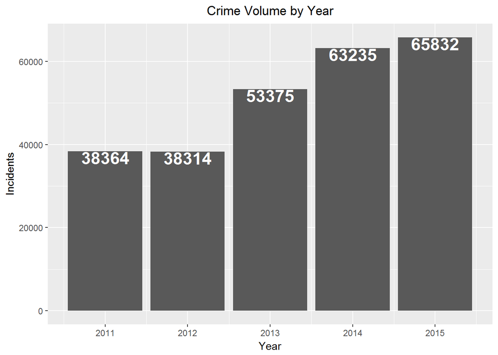

[figure not shown]

barplotCrime

```r
df = data %>%
  filter(IS_CRIME==1) %>%
  filter(year!=max(year(date))) %>%
  group_by(year) %>%
  summarise(incidents=sum(IS_CRIME)) %>%
  arrange(year)

p = ggplot(df,aes(x=year,y=incidents,label=incidents))
p + geom_bar(stat='identity') + geom_text(fontface='bold',size=6,col='white',vjust=1)+ ggtitle('Crime Volume by Year') + xlab('Year') + ylab('Incidents') + theme(plot.title = element_text(hjust = 0.5))
```

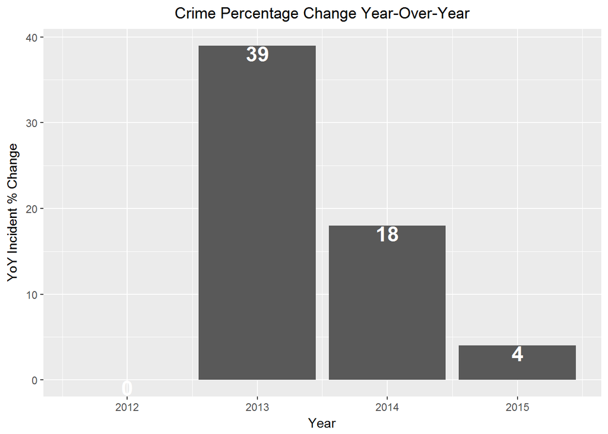

[figure not shown]

barplotCrimeChange

```r
df = data %>%
  filter(IS_CRIME==1) %>%
  filter(year!=max(year(date))) %>%
  group_by(year) %>%
  summarise(incidents=sum(IS_CRIME)) %>%
  arrange(year) %>%
  mutate(year,YoYPercentageChange=round(100*(incidents-lag(incidents))/lag(incidents)),0)
df = df[!is.na(df$YoYPercentageChange),]
p = ggplot(df,aes(x=year,y=YoYPercentageChange,label=YoYPercentageChange))
p + geom_bar(stat='identity') + geom_text(fontface='bold',size=6,col='white',vjust=1)+ ggtitle('Crime Percentage Change Year-Over-Year') + xlab('Year') + ylab('YoY Incident % Change') + theme(plot.title = element_text(hjust = 0.5))
```

**Observations** Crime rose the most between 2013 and 2012 (39% increase) * Crime increased each year after but at a decreasing rate * Examine years 2012 - 2014 to see growth changes

**Highest volume of “IS_CRIME” types**  
Identify the offense by OFFENSE_CATEGORY_ID and exclude months we have not seen so far this year.

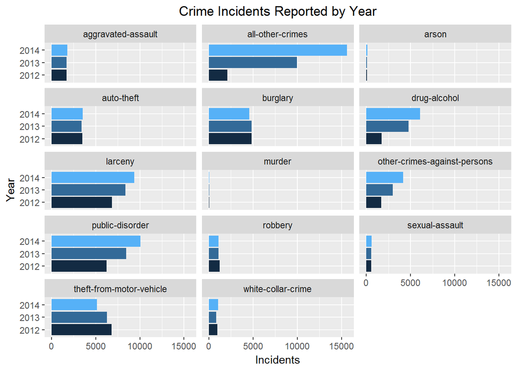

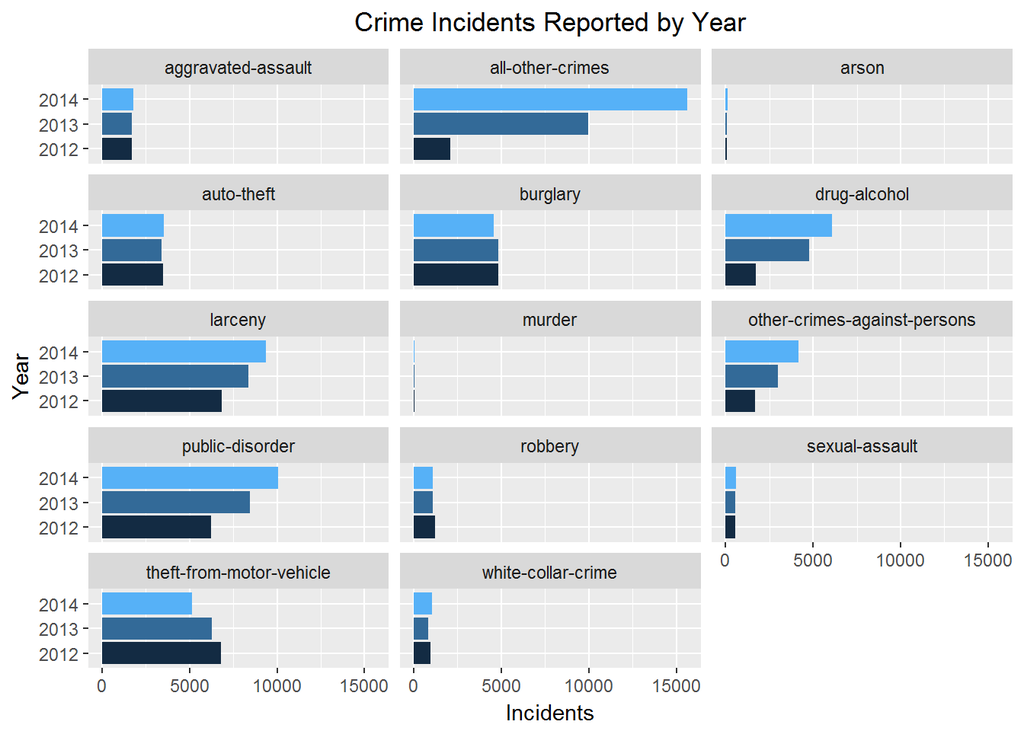

barplotCrimeCategories

```r
#Isolate Years 2012 - 2014
data = data[data$year <= 2014 & data$year >= 2012,]

#Sum up all incidents IS_CRIME AND IS_TRAFFIC
maxYear = max(data$year)
maxMonthYTD = max(data$month[data$year==maxYear])

#Look into IS_CRIME only
df = data %>%
  filter(IS_CRIME==1) %>%
  group_by(year,OFFENSE_CATEGORY_ID) %>%
  summarise(incidents=sum(IS_CRIME)) %>%
  arrange(desc(incidents))

p = ggplot(df,aes(x=factor(year),y=incidents,fill=year))
p + geom_bar(stat='identity') + ggtitle('Crime Incidents Reported by Year') + xlab('Year') + ylab('Incidents') + theme(plot.title = element_text(hjust = 0.5),legend.position = 'none') + guides(fill = guide_legend(title='Year')) + coord_flip() + facet_wrap(~OFFENSE_CATEGORY_ID,ncol=3)
```

**Observations**  
It would appear as if “all-other-crimes” has moved the needle the most between 2012 - 2014. This is not a very specific category. It’s also worth noticing that “other-crimes-against-persons” has grown as well. Both of these leads to some speculation that perhaps these vague types of crimes started being reported during this period and perhaps hadn’t been documented before.

- Growth categories:
- “larceny”
- “drug-alcohol”
- “public-disorder”
- Declining categories:
- “theft-from-motor-vehicle”
- “robbery”
- “burglary”

Many of the other categories have a much lower volume of incidents. Growth is more difficult to see in visualizatoins for these cases.

**Here’s a look at growth year-over-year:**

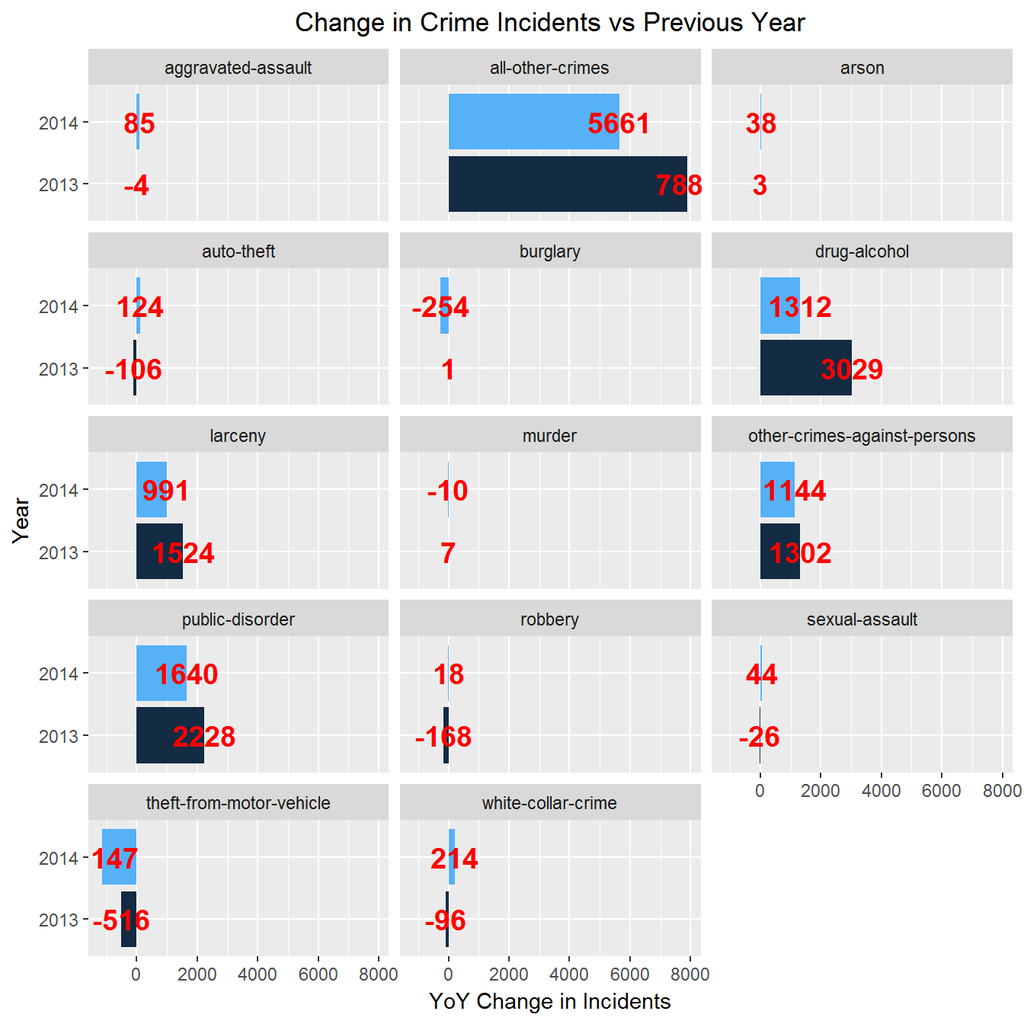

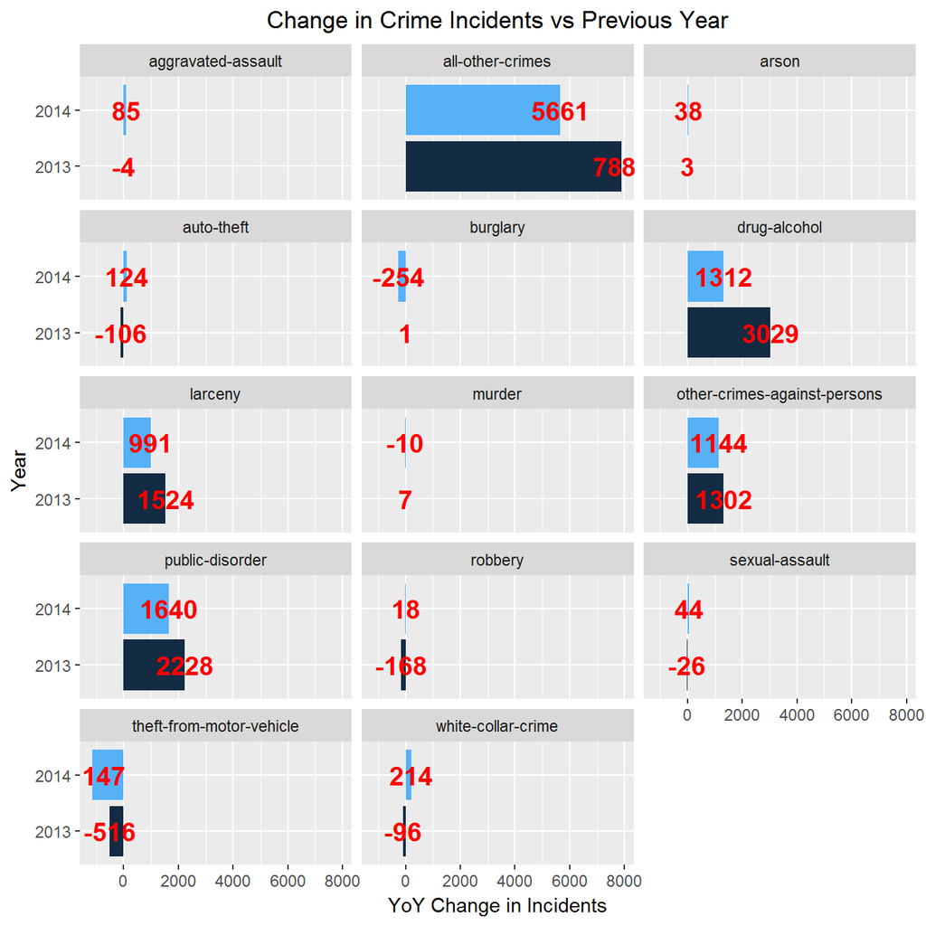

barplotCrimeCategoryChange

```r
df2 = df %>%
  group_by(OFFENSE_CATEGORY_ID) %>%
  arrange(OFFENSE_CATEGORY_ID,year) %>%
  mutate(year,YoYchange=round((incidents-lag(incidents))),0) %>% filter(year != 2012)

p = ggplot(df2,aes(x=factor(year),y=YoYchange,fill=year,label=YoYchange))
p + geom_bar(stat='identity') + ggtitle('Change in Crime Incidents vs Previous Year') + xlab('Year') + ylab('YoY Change in Incidents') + theme(plot.title = element_text(hjust = 0.5),legend.position = 'none') + guides(fill = guide_legend(title='Year')) + coord_flip() + facet_wrap(~OFFENSE_CATEGORY_ID,ncol=3) + geom_text(hjust=0.5, size=5,col='red', fontface='bold')
```

**Here’s a look at % growth year-over-year:**

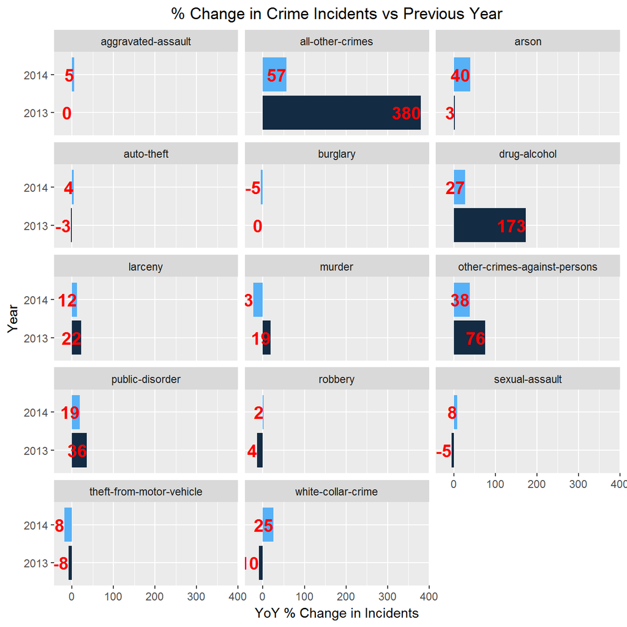

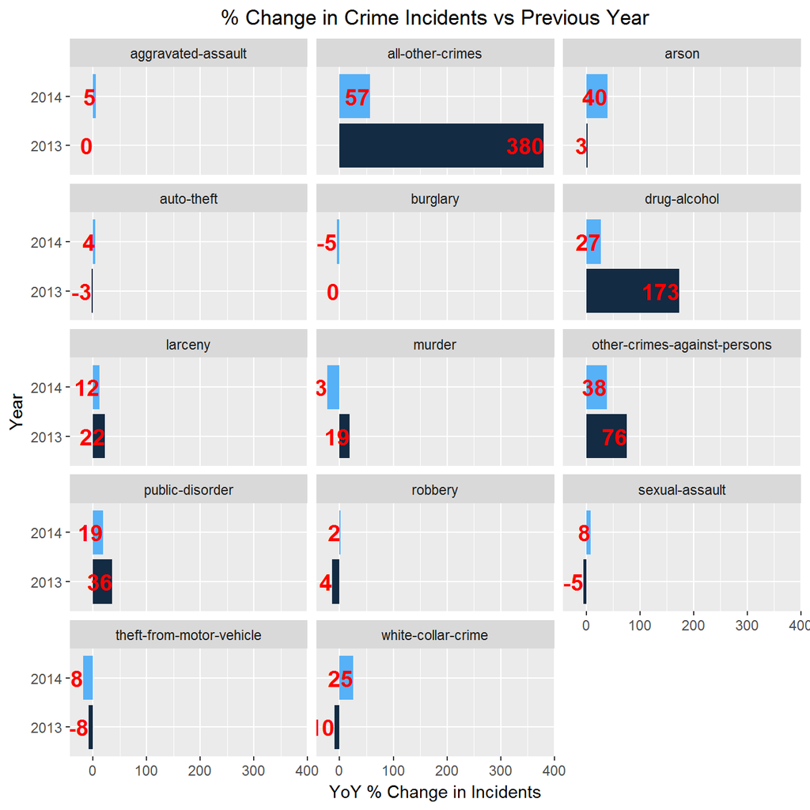

barplotCrimeCategoryPercentageChange

```r
df2 = df %>%
  group_by(OFFENSE_CATEGORY_ID) %>%
  arrange(OFFENSE_CATEGORY_ID,year) %>%
  mutate(year,YoYchange=round(100*((incidents-lag(incidents))/lag(incidents))),0) %>% filter(year != 2012)

p = ggplot(df2,aes(x=factor(year),y=YoYchange,fill=year,label=YoYchange))
p + geom_bar(stat='identity') + ggtitle('% Change in Crime Incidents vs Previous Year') + xlab('Year') + ylab('YoY % Change in Incidents') + theme(plot.title = element_text(hjust = 0.5),legend.position = 'none') + guides(fill = guide_legend(title='Year')) + coord_flip() + facet_wrap(~OFFENSE_CATEGORY_ID,ncol=3) + geom_text(hjust=1,col='red',size=5,fontface='bold')
```

**Observations**

- “all-other-crimes” is the outright leader in change in both volume and percentage growth year-over-year with an astonishing 380% increase between 2012 and 2013
- “drug-alcohol” grew by 173% between 2012 and 2013 but dropped down to only 27% growth the next year
- “murder” didn’t change too much in volume compared to everything else (swinging up 7 and down 10) but was a 19% growth and a 23% decline in 2013 and 2014 respectively

**Final Thoughts (for now)** Due to the vague nature of the types of crimes which grew the most, I can’t determine exactly what happened in Denver during 2013. In the less vague crimes, “drug-alcohol” saw the largest increase. This was followed by “public-disorder” and perhaps there’s a relationship there. My assumption is that one may perhaps cause the other…

I’m still curious about the seasonality and month-to-month effects. Perhaps certain types of crimes are more common during certain times. I’m also very interested to see if a new population was perhaps added to the mix in 2013. If a certain part of Denver was added in 2013 that would certainly help to explain the situation.

**What I’ll do in the next crime posts**

- Look for patterns by location
- Lay out some visualizations on maps
- Try to identify areas with high volumes of traffic incidents (maybe I can avoid a ticket)
- Answer the question: What types of crimes have grown the most in the last 5 years?

My code for this is posted on GitHub:  
https://github.com/stoltzmaniac/Denver-Crime-Analysis.git